# Лабораторная работа №13

Операционные системы

Гасанова Ш. Ч.

Российский университет дружбы народов, Москва, Россия

9 мая 2025

## Цель

Научится писать более сложные командные файлы с использованием логических управляющих конструкций и циклов.

## Задание

1. Используя команды getopts grep, написать командный файл, который анализирует командную строку с ключами:
- iinputfile
- ooutputfile
- pшаблон
- C
- n а затем ищет в указанном файле нужные строки, определяемые ключом -p.
2. Написать на языке Си программу, которая вводит число и определяет, является ли оно больше нуля, меньше нуля или равно нулю. Затем программа завершается с помощью функции exit(n), передавая информацию в о коде завершения в оболочку. Командный файл должен вызывать эту программу и, проанализировав с помощью команды $?, выдать сообщение о том, какое число было введено.

## Задание

3. Написать командный файл, создающий указанное число файлов, пронумерованных последовательно от 1 до N (например 1.tmp, 2.tmp, 3.tmp,4.tmp и т.д.). Число файлов, которые необходимо создать, передаётся в аргументы командной строки. Этот же командный файл должен уметь удалять все созданные им файлы (если они существуют).
4. Написать командный файл, который с помощью команды tar запаковывает в архив все файлы в указанной директории. Модифицировать его так, чтобы запаковывались только те файлы, которые были изменены менее недели тому назад (использовать команду find).

## Выполнение лабораторной работы

Создаю файл 13-1.sh и пишу там скрипт, который который анализирует командную строку с приведёнными ключами, а затем ищет в указанном файле нужные строки

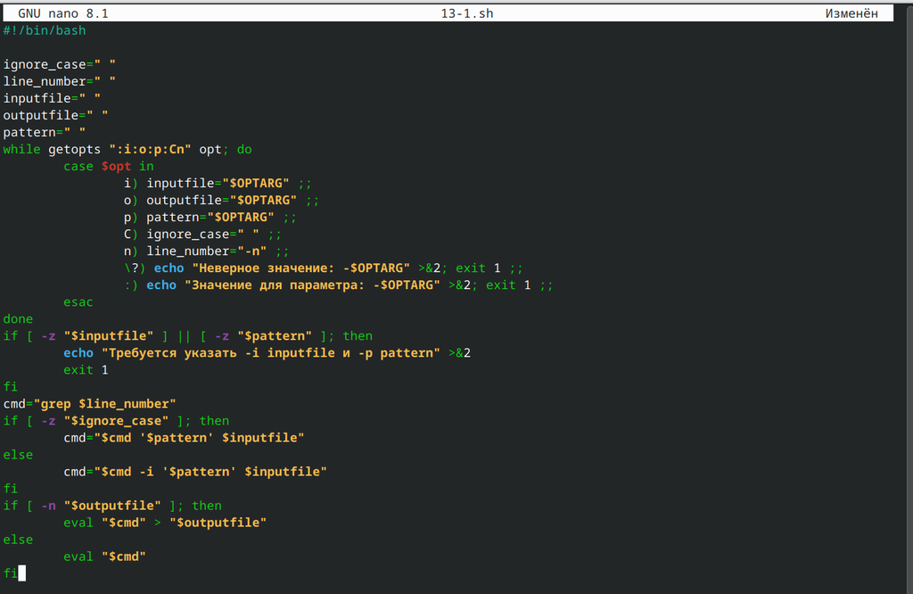

Первый скрипт

## Выполнение лабораторной работы

Делаю файл исполняемым, проверяю работоспособность

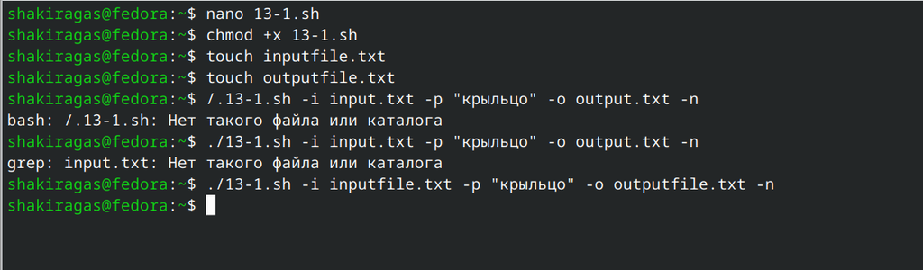

Запуск файла

## Выполнение лабораторной работы

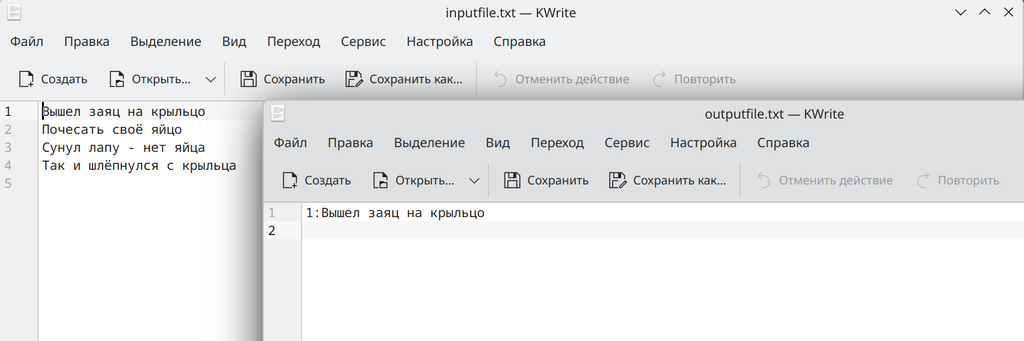

Проверка

## Выполнение лабораторной работы

Создаю файл 13-2.c и пишу на языке Си программу, которая выводит число и сравнивает его с нулём

[figure not shown]

Программа

## Выполнение лабораторной работы

Пишу командный файл 13-2.sh, который вызывает программу (13-2.c) и выдаёт сообщение о том, какое число было введено

[figure not shown]

Второй скрипт

## Выполнение лабораторной работы

Делаю файл исполняемым, проверяю работу

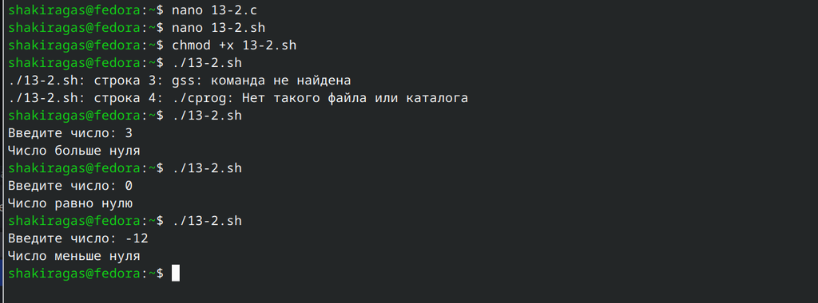

Проверка

## Выполнение лабораторной работы

Создаю файл 13-3.sh и пишу командный файл, создающий указанное число файлов, пронумерованных последовательно от 1 до N, а затем удаляет их

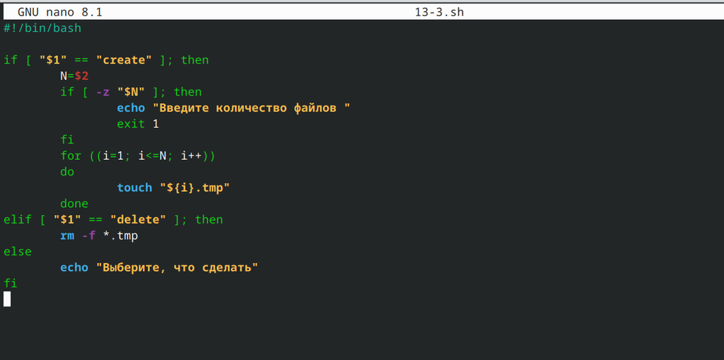

Третий скрипт

## Выполнение лабораторной работы

Делаю файл исполняемым, проверяю

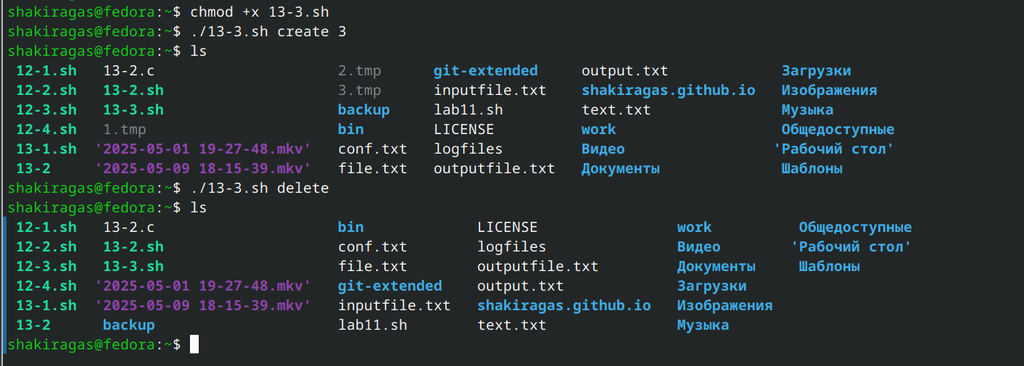

Проверка

## Выполнение лабораторной работы

Пишу командный файл 13-4.sh, который с помощью команды tar запаковывает в архив все файлы в указанной директории

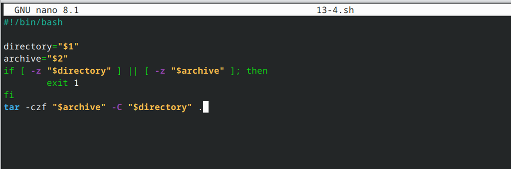

Четвёртый скрипт

## Выполнение лабораторной работы

Проверяю созданный архив

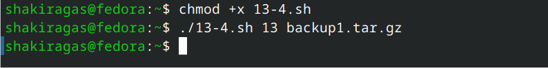

Исполнение файла

## Выполнение лабораторной работы

[figure not shown]

Архив

## Выполнение лабораторной работы

Модифицирую файл, чтобы запаковывал только те файлы, которые были изменены за последнюю неделю

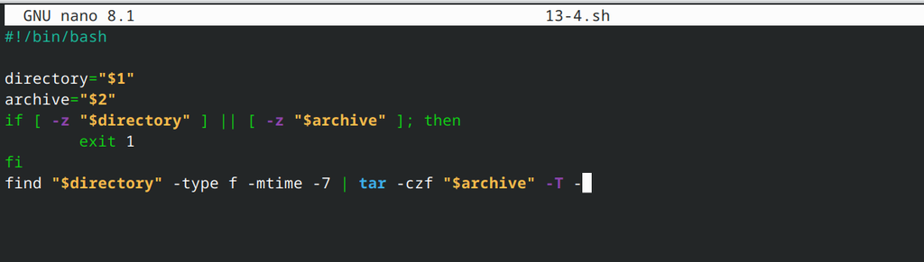

Модификация скрипта

## Выполнение лабораторной работы

Проверяю созданный архив

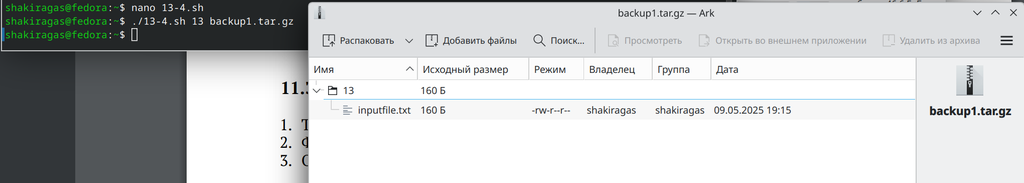

Исполнение файла

## Выводы

При выполнении данной лабораторной работы я научилась писать более сложные командные файлы с использованием логических управляющих конструкций и циклов.

## Список литературы

1. Лабораторная работа №13 [Электронный ресурс]